Produced Saturday 14 November 2020

**This is one page of the R Handbook for Epidemiologists, but is being printed as a stand-alone page.**

**You can find the complete handbook on [Github](https://github.com/nsbatra/Epi_R_handbook)**

# Age pyramids

## Overview

via ggplot and via R4Epis methods TODO

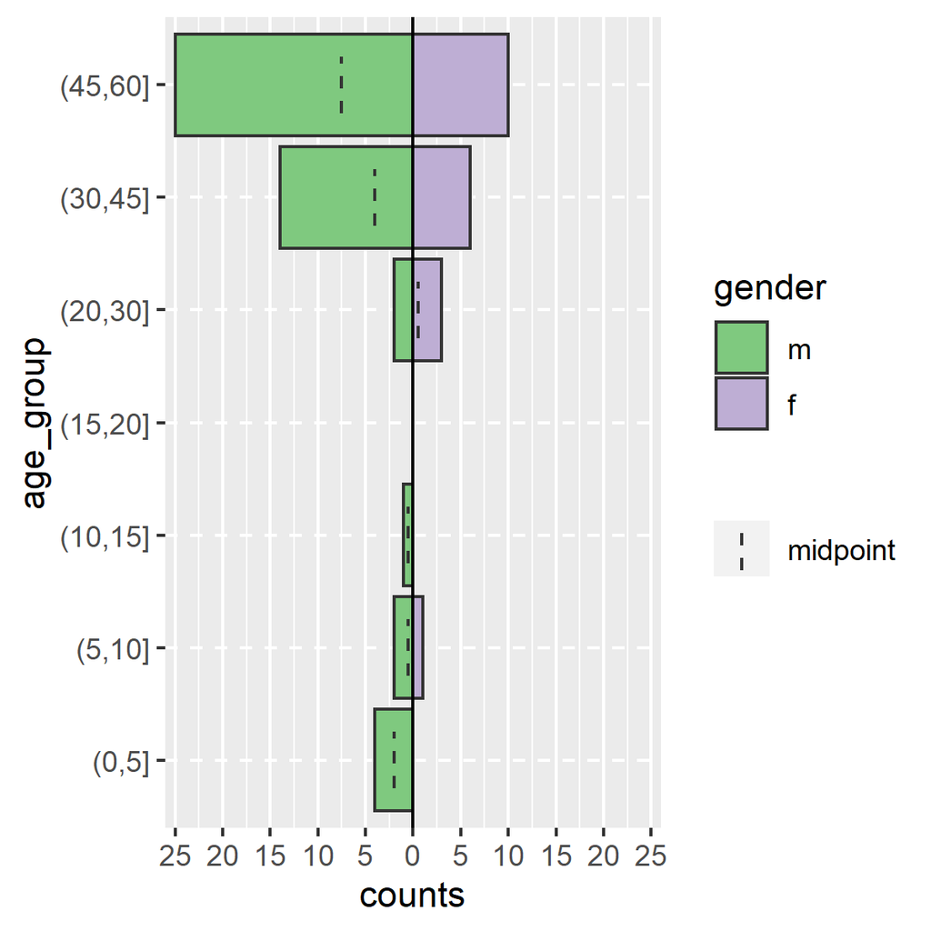

## Preparation

To make a traditional age/sex demographic pyramid, the data must first be cleaned in the following ways:

- The gender column must be cleaned.
- The age column must be numeric, cleaned, and grouped into age groups

### Setup and Importing the data

First, load the packages required for this analysis:

```r
pacman::p_load(rio,       # to import data
               here,      # to locate files
               tidyverse, # to clean, handle, and plot the data (includes ggplot package)
               apyramid   # a package dedicated to creating age pyramids
               )
```

Now import the data

```r
linelist <- import(here("data", "fluH7N9_China_2013.csv"))
```

### Clean values

#### Clean age values

Sometimes, age variables will import as class “character”. This occurs most often if there are non-numeric characters in some of the values, for example entries of “2 months”, or how in some countries commas are used in the decimals place (e.g. “4,5” to mean four and one half years)

In other circumstances, a numeric age variable may be adjacent to another “units” variable (values of either years or months). This will require additional cleaning to calculate a completely numeric age. You can find an example of this in the *cleaning page* (LINK).

```r
#check the class of the linelist variable age
class(linelist$age)
```

```
## [1] "character"
```

```r
# ensure class of age variable is numeric, by re-defining itself
linelist$age <- as.numeric(linelist$age)
```

Now create age groups. There are a few ways to do this. The most simple way is using the **base** function `cut()`, which creates groups from a numeric variable.  
First you give the numeric variable to be cut (age), the the *breaks* argument which is a vector (`c()`) of number break points.

By default, the grouping occurs so that the right/upper side is “open” and inclusive (and the left/lower side is “closed” or exclusive). The default labels use the notation “(A, B]”, which means the group does not include A (the lower break), but includes B (the upper break). You can reverse this behavior by providing the *right* argument and setting equal to `FALSE` (explanation below).

```r
# Create new variable, by cutting the numeric age variable
linelist$age_group <- cut(linelist$age,
                          breaks = c(0, 5, 10, 15, 20, 30, 45, 100))

# tabulate the number of observations per group
table(linelist$age_group)
```

```
##
##    (0,5]   (5,10]  (10,15]  (15,20]  (20,30]  (30,45] (45,100]
##        4        3        1        0        5       20      101
```

You may want to verify that each age was assigned to the correct group. You can do this by cross-tabulating the age and age_group variables (names added for clarity). For example, you can check that the one 15-year patient was correctly assigned.

```r
table(age = linelist$age, age_group = linelist$age_group, useNA = "always")
```

```
##       age_group
## age    (0,5] (5,10] (10,15] (15,20] (20,30] (30,45] (45,100] <NA>
##   2        1      0       0       0       0       0        0    0
##   4        3      0       0       0       0       0        0    0
##   6        0      1       0       0       0       0        0    0
##   7        0      1       0       0       0       0        0    0
##   9        0      1       0       0       0       0        0    0
##   15       0      0       1       0       0       0        0    0
##   21       0      0       0       0       1       0        0    0
##   25       0      0       0       0       1       0        0    0
##   26       0      0       0       0       2       0        0    0
##   27       0      0       0       0       1       0        0    0
##   31       0      0       0       0       0       2        0    0
##   32       0      0       0       0       0       2        0    0
##   34       0      0       0       0       0       1        0    0
```

[output cut: 48 more lines]

**NOTE:** Note that if you provide a highest break value that is too low, values may be excluded accidentally! You can write code that automatically adapts, by replacing the static number with the `max()` function, as below. Don’t forget to include `na.rm` argument to `max()` so that missing values are excluded from the maximum calculation (see LINK to description of max function).

```r
linelist$age_group <- cut(linelist$age,
                          breaks = c(0, 5, 10, 15, 20, 30, 45, max(linelist$age, na.rm=T)))
table(linelist$age_group)
```

```
##
##   (0,5]  (5,10] (10,15] (15,20] (20,30] (30,45] (45,91]
##       4       3       1       0       5      20     101
```

It may be important to also include the argument *include.lowest* and set it equal to `TRUE`, so that any values of 0 are still included in the lowest group (this could apply if infants have been coded as age 0). Customized group labels can be added manually with the *labels* argument. Both are shown below:

```r
linelist$age_group <- cut(linelist$age,
                          breaks = c(0, 5, 10, 15, 20, 30, 45, 60),
                          include.lowest = TRUE,
                          labels = c("0-5", "6-10", "11-15", "16-20", "21-30", "31-45", "46-60"))

table(linelist$age_group)
```

```
##
##   0-5  6-10 11-15 16-20 21-30 31-45 46-60
##     4     3     1     0     5    20    35
```

```r
linelist$age_group <- cut(linelist$age,
                          breaks = c(0, 5, 10, 15, 20, 30, 45, 60),                              # same breaks
                          right = FALSE,                                                         # change the inclusion
                          include.lowest = TRUE,                                                 # same, but now applies to highest break
                          labels = c("0-4", "5-9", "10-14", "15-19", "20-29", "30-44", "45-59")) # now the labels must change

table(linelist$age_group)
```

```
##
##   0-4   5-9 10-14 15-19 20-29 30-44 45-59
##     4     3     0     1     5    19    36
```

If you want a fast way to make breaks and labels, you can use this:

```r
# TO DO - NOT CORRECT


# Make groups from 0 to 90 by 5
age_seq = seq(from = 0, to = 90, by = 5)

# Make labels for the above
age_lab = paste0(age_seq, "-", age_seq + 4)
length(age_seq)
```

```
## [1] 19
```

```r
length(age_lab)
```

```
## [1] 19
```

```r
# # Use these in the cut() command
# linelist$age_group <- cut(linelist$age,
#                           breaks = age_seq,
#                           labels = age_lab)
```

#### Clean gender values

Create a table of the values in the variable “Gender”

```r
table(linelist$gender, useNA = "always")
```

```
##
##    f    m <NA>
##   39   95    2
```

Take the opportunity to make changes or clean any incorrect values.

## **apyramid** package

The package **apyramid** allows you to quickly make an age pyramid. For more nuanced situations, see the tab on using `ggplot()` to make age pyramids. You can read more about the **apyramid** package by entering `?age_pyramid` in your R console.

First we load the package (if not already done)

```r
#load package
pacman::p_load(apyramid)
```

Now, using the cleaned dataset (see previous tabs), we can create an age pyramid with just one command.

- The *data* argument is set as the `linelist` dataframe
- The *age_group* argument (y-axis) is set to the name of your grouping variable (in quotes)
- The *split_by* argument (colors) in this case is set to our “gender” variable. You can also use other variables.

*Note: If the split_by variable is bivariate (e.g. male/female, or yes/no), then the result will show up as a pyramid, otherwise, it will be presented as a facetted barplot with with empty bars in the background indicating the range of the un-facetted data set. Values of split_by will show up as labels at top of each facet.*

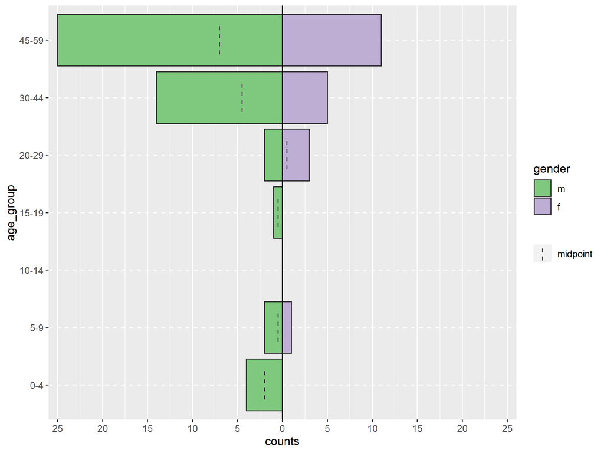

```r
apyramid::age_pyramid(data = linelist,
                      age_group = "age_group",
                      split_by = "gender")
```

By default, the bars display counts (not %), a dashed mid-line for each group is shown, the colors are green/purple, and missing values are not shown. These can all be adjusted, as shown below:

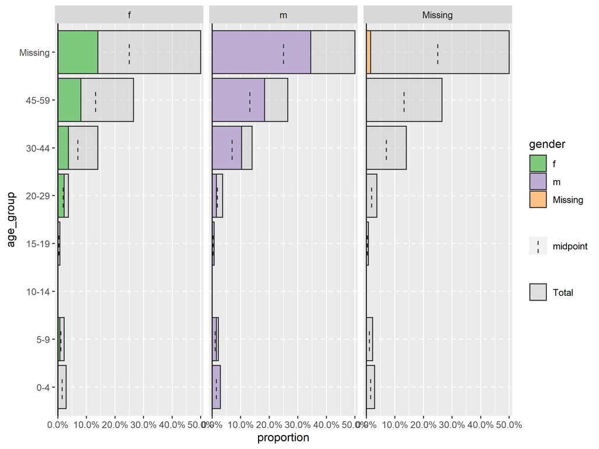

```r
apyramid::age_pyramid(data = linelist,
                      age_group = "age_group",
                      split_by = "gender",
                      proportional = TRUE, # show percents, not counts
                      na.rm = FALSE        # show a bar for patients missing age
                      )
```

You can always add additional `ggplot()` commands to the plot using the standard `ggplot()` “+” syntax, such as aesthetic themes and label adjustments:

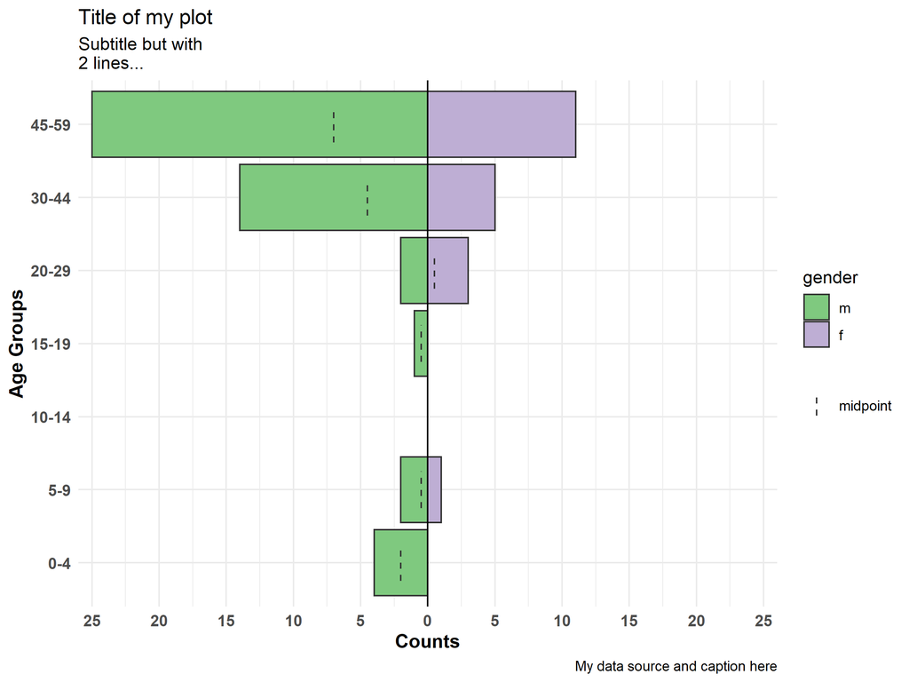

```r
apyramid::age_pyramid(data = linelist,
                      age_group = "age_group",
                      split_by = "gender")+
  theme_minimal()+         # this is a standard ggplot() theme that simplifies the aesthetic background
  labs(y = "Counts",       # note that for age pyramids the x and y labels are switched.
       x = "Age Groups",   # Read more about this in the ggplot() age pyramid tab
       caption = "My data source and caption here",
       title = "Title of my plot",
       subtitle = "Subtitle but with \n2 lines...")+
  theme(axis.text = element_text(size = 10, face = "bold"),    # see ggplot() tips page for details
        axis.title = element_text(size = 12, face = "bold"))
```